# 4.1 Basic statistics

If you want to describe a dice, probability is what you use. If you have two dice, still so… but as you gather enough dice and study their collective behavior, you effectively enter the realm of statistics — the field of “many stochastic variables”. We also want to study data that does not stem from throwing dice or flipping coins. Here we will introduce you to the language used.

You have already studied statistics, but some sections here are likely still new to you. In particular, learn how to do statistical analysis using R.

## Review: Statistical distributions in general

**Introduction:** Watch this video on how we move from probability to statistics. *If you think this topic is rather basic, you can skip to doing the exercises below using R.*

- Video: *4.3 From probability to statistics* (Canvas/Kaltura)
- Watch this video: https://www.youtube.com/watch?v=CfZa1daLjwo&list=PLaFfQroTgZnzbfK-Rie19FdV6diehETQy
- Also watch a video showing in more detail how distributions behave (Canvas/Kaltura: *Demo of statistical distributions v2*).
- The demo used is browsable at http://demo-statdist.serve.scilifelab.se
- Optional: [this video](https://www.youtube.com/watch?v=b9a27XN_6tg&list=PLaFfQroTgZnzbfK-Rie19FdV6diehETQy&index=2) shows further examples of statistical distributions.
- Some possibly great solved examples: https://www.youtube.com/watch?v=zJ8e_wAWUzE

**Practice statistical distribution analysis using the demo (optional):**

- **Q1.1**. You have a stochastic variable X following a normal distribution, with mean 3 and standard deviation 5. What is the probability of X being greater than 7?

**Hint**

Standardize: how many standard deviations above the mean is 7? Then read off the upper tail of a standard normal.

**Hint**

z = (7 - 3) / 5 = 0.8. You want P(Z > 0.8) for Z ~ N(0,1).

**Solution**

```r
1 - pnorm(7, mean = 3, sd = 5)
```

```
[1] 0.2118554
```

Roughly 0.21.

- **Q1.2**. Assume Z ~ N(0,2). What is P(Z > 10)?

**Hint**

Watch the parameterisation: in R’s `pnorm`, the second parameter of N(μ, σ) is the standard deviation, not the variance. Many textbooks use variance — check which is meant here.

**Solution**

Reading N(0,2) as μ=0, σ=2:

```r
1 - pnorm(10, mean = 0, sd = 2)
```

```
[1] 2.866516e-07
```

Essentially zero (5 sigma away).

- **Q1.3**. Assume Z ~ N(0,3). What is P(Z > 2 & Z < 5)?

**Hint**

P(a < Z < b) = F(b) - F(a), where F is the cumulative distribution function.

**Solution**

```r
pnorm(5, mean = 0, sd = 3) - pnorm(2, mean = 0, sd = 3)
```

```
[1] 0.2047022
```

**Practice statistical distribution analysis using R (this is likely new to you!):**

- **Q2.1**. Look at the [R help for the normal distribution](https://www.rdocumentation.org/packages/stats/versions/3.6.2/topics/Normal).

**Hint**

In R, `?Normal` or `?pnorm` opens the help page. Note the four functions: `dnorm` (density), `pnorm` (CDF), `qnorm` (quantile), `rnorm` (random).

**Solution**

```r
?Normal
?pnorm
```

- **Q2.2**. Produce 3 random numbers that are normally distributed with mean 3 and sigma 5.

**Hint**

The `r` prefix in `rnorm` stands for “random”.

**Solution**

```r
rnorm(3, mean = 3, sd = 5)
```

```
[1] 1.617992 4.524599 5.313646
```

- **Q2.3**. Assume X ~ N(0,1). What is P(X > 0)? (you don’t need R to compute this; but check that the answer from R makes sense)

**Hint**

By symmetry the answer should be exactly 0.5. Use `pnorm` to confirm.

**Solution**

```r
1 - pnorm(0, mean = 0, sd = 1)
```

```
[1] 0.5
```

- **Q2.4**. Assume X ~ N(0,2). What is P(X > 10)?

**Hint**

Same as Q1.2 — `1 - pnorm(...)` for the upper tail.

**Solution**

```r
1 - pnorm(10, mean = 0, sd = 2)
```

```
[1] 2.866516e-07
```

- **Q2.5**. Assume X ~ N(0,5). What is P(X > 10 & X < 20)?

**Hint**

Subtract two CDF evaluations: P(10 < X < 20) = F(20) - F(10).

**Solution**

```r
pnorm(20, mean = 0, sd = 5) - pnorm(10, mean = 0, sd = 5)
```

```
[1] 0.02271846
```

- **Q2.6.** Optional: verify the answers above using the visual demo.

**Hint**

Open http://demo-statdist.serve.scilifelab.se, pick a normal distribution, set μ and σ to match the question, then shade the region of interest.

**Solution**

Visual check only — the shaded area in the demo should agree (within rounding) with the values returned by `pnorm`.

- **Q2.7**. Assume X ~ Binom(theta=0.5, n=10); what is P(X=10)? Note that since the binomial distribution is discrete, you can here use the probability density function directly rather than using the cumulative density function (but either works).

**Hint**

For a discrete distribution, the “density” `dbinom(k, size, prob)` gives P(X = k) directly.

**Solution**

```r
dbinom(10, size = 10, prob = 0.5)
```

```
[1] 0.0009765625
```

- **Q2.8**. Verify above using basic probability theory. This case is a simple special case!

**Hint**

P(all 10 flips heads) = (1/2)^10.

**Solution**

```r
0.5^10
```

```
[1] 0.0009765625
```

1/1024 ≈ 0.000977, matching `dbinom`.

## The Poisson distribution

**Introduction:** This is one of the most fundamental distributions for handling discrete counts, as we get from DNA sequencers, or from Geiger counters for radiation. It arises whenever you have a memory-less process, emitting N events/second. A common example is traffic flow although in reality it follows much more complicated patterns.

- Video of the definition and some solved examples: https://www.youtube.com/watch?v=jmqZG6roVqU
- Video of some examples when a process is not Poisson. In general, whenever events are correlated for some reason, this property breaks down. This turns out especially important for single-cell analysis: https://www.youtube.com/watch?v=sv_KXSiorFk

**Practice the Poisson distribution:**

Assume X ~ Poisson(1).

- **Q3.1.** What is P(x=0)? P(x=1)?

**Hint**

`dpois(k, lambda)` gives the Poisson probability mass at k.

**Solution**

```r
dpois(0, lambda = 1)
```

```
[1] 0.3678794
```

```r
dpois(1, lambda = 1)
```

```
[1] 0.3678794
```

Both equal 1/e ≈ 0.368.

- **Q3.2.** Plot a barplot of P(X=n) for n=0…10.

**Hint**

Build a vector with `dpois(0:10, lambda = 1)` and feed it to `barplot()`. Use `names.arg = 0:10` to label the bars.

**Solution**

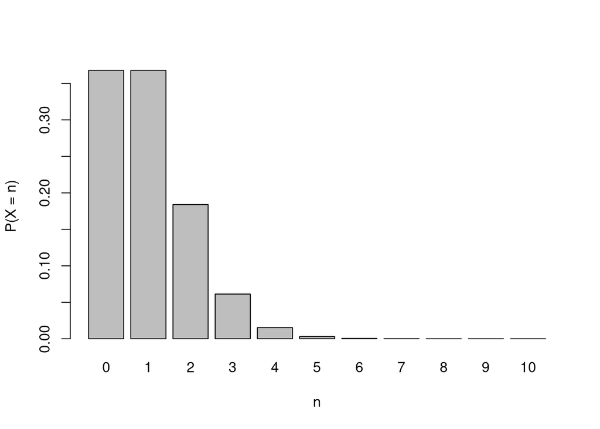

```r
n <- 0:10
barplot(dpois(n, lambda = 1), names.arg = n,
        xlab = "n", ylab = "P(X = n)")
```

- **Q3.3.** What is P(x ≥ 4)?

**Hint**

You can either integrate, or you can relate this to P(x=0), P(x=1), P(x=2) and P(x=3).

**Hint**

`ppois(q, lambda)` returns P(X ≤ q). So P(X ≥ 4) = 1 - P(X ≤ 3).

**Solution**

```r
1 - ppois(3, lambda = 1)
```

```
[1] 0.01898816
```

```r
# equivalently:
ppois(3, lambda = 1, lower.tail = FALSE)
```

```
[1] 0.01898816
```

```r
# or by summation:
1 - sum(dpois(0:3, lambda = 1))
```

```
[1] 0.01898816
```

Counting DNA or RNA molecules is approximately Poisson-distributed. However, since we PCR-amplify them and produce copies (correlated!), this approximation breaks down if we pick too many molecules. Go to https://demo-poisson.serve.scilifelab.se and the tab “repeated sampling”. You can set how many molecules you have originally in a tube, and how many molecules you sample using a sequencer.

- **Q3.4.** For 100 molecules, how many samples can you take while keeping doublets < 10%? Does this fit with your intuition?
  - number of points = how many molecules you can sample from
  - number of samples = how many molecules you pick
  - The table below shows the distribution of how many times a molecule has been sampled. If you don’t sample at all, 100% of points will have numsamples=0.

**Hint**

Random seed controls the random sampling. Try different seeds to see how trying again affects the variation in your answer. Singlets are those with numsamples=1.

**Hint**

Analytically: if you sample s molecules from N=100 with replacement, the expected occupancy per molecule is λ = s/N. The fraction of molecules hit ≥ 2 times is roughly 1 - (1+λ)e^(-λ). Solve for when this is 0.1.

**Solution**

```r
# Fraction of molecules sampled >= 2 times, as a function of total samples s,
# for N = 100 molecules.
N <- 100
s <- 1:100
lambda <- s / N
doublet_frac <- 1 - ppois(1, lambda)   # P(X >= 2)
data.frame(s = s, doublet_frac = round(doublet_frac, 3))[s %in% c(10, 20, 30, 50, 70), ]
```

```
    s doublet_frac
10 10        0.005
20 20        0.018
30 30        0.037
50 50        0.090
70 70        0.156
```

Doublet rate crosses 10% somewhere around s ≈ 50–55 samples; the demo should agree.

Optional related reading: [The birthday problem/paradox](https://en.wikipedia.org/wiki/Birthday_problem).

## Statistical testing in R

**Introduction:** Watch this video to learn how to perform basic statistical testing (Canvas/Kaltura: *4.1 Statistical_testing*).

Pay particular attention to:

- What is the mean and variance of the average?
- Why do we assume the average to have a normal distribution?
- How do you integrate the normal distribution to get p-values?

**Practice statistical testing using R:**

- Look up the [R help for t-testing](https://www.rdocumentation.org/packages/stats/versions/3.6.2/topics/t.test).
- **Q4.1.** Investigate `diabetes.csv`. Perform a t-test to check if the BMI of those with `Outcome=1` (i.e. those getting diabetes) is higher than those who do not. Is this a paired test?

**Hint**

Read the CSV with `read.csv()`, then split BMI by `Outcome` and feed the two vectors to `t.test()`. Use `alternative = "greater"` for a one-sided test.

**Hint**

“Paired” means each observation in group A has a natural partner in group B (e.g. before/after on the same patient). Here the two groups are different patients — so no.

**Solution**

```r
d <- read.csv("diabetes.csv")
bmi_pos <- d$BMI[d$Outcome == 1]
bmi_neg <- d$BMI[d$Outcome == 0]
t.test(bmi_pos, bmi_neg, alternative = "greater")
# equivalently using the formula interface:
t.test(BMI ~ Outcome, data = d, alternative = "less")  # 0 < 1 ordering
```

Not a paired test — the two groups are different individuals, with different sample sizes.

- **Q4.2.** For “large” number of samples, you can also perform a non-parametric test, which makes fewer assumptions about the distribution of the samples. One such is `wilcox.test()`; how does it seem to compare to the t-test here?

**Hint**

Same call signature as `t.test()`. Compare the p-values; for reasonably symmetric, large-N data they should be in the same ballpark.

**Solution**

```r
d <- read.csv("diabetes.csv")
bmi_pos <- d$BMI[d$Outcome == 1]
bmi_neg <- d$BMI[d$Outcome == 0]
wilcox.test(bmi_pos, bmi_neg, alternative = "greater")
```

Both tests give very small p-values here — BMI is clearly higher in the diabetic group. The Wilcoxon makes no normality assumption but tends to be slightly less powerful when normality actually holds.

- **Q4.3.** Optional: Perform similar tests on other variables in `diabetes.csv`; does it match your expectations?

**Hint**

Loop over the numeric columns and apply `t.test(col ~ Outcome, data = d)`. Watch out for columns where a value of 0 actually means “missing” (e.g. `Insulin`, `SkinThickness`).

**Solution**

```r
d <- read.csv("diabetes.csv")
vars <- setdiff(colnames(d), "Outcome")
pvals <- sapply(vars, function(v) {
  t.test(d[[v]] ~ d$Outcome)$p.value
})
sort(pvals)
```

Glucose, BMI, Age and Pregnancies all separate the two groups strongly — consistent with known risk factors for type 2 diabetes. Variables like `BloodPressure` and `SkinThickness` separate less clearly, partly because zeros in the raw data encode missing values.

## Extra exercise material

A second pass at the same material, for extra practice. Same conventions as above — try each question first, then peek.

### Distributions (extra)

- **QE1.1**. Assume X ~ N(10, 2) (i.e. μ=10, σ=2). What is P(X < 8)?

**Hint**

`pnorm(q, mean, sd)` returns P(X ≤ q) directly. No need to subtract from 1 for a lower-tail question.

**Solution**

```r
pnorm(8, mean = 10, sd = 2)
```

```
[1] 0.1586553
```

Roughly 0.16 — one σ below the mean.

- **QE1.2**. Assume X ~ N(100, 15) (a classic IQ-style parameterisation). What fraction of the population has X between 85 and 130?

**Hint**

P(a < X < b) = F(b) - F(a).

**Solution**

```r
pnorm(130, mean = 100, sd = 15) - pnorm(85, mean = 100, sd = 15)
```

```
[1] 0.8185946
```

About 0.82.

- **QE1.3**. Assume X ~ N(0, 1). Find the value `x` such that P(X > x) = 0.025. (This is the classic critical value used to build a 95% confidence interval.)

**Hint**

This is the inverse problem — given a probability, recover the quantile. Use `qnorm`.

**Hint**

`qnorm` returns the lower-tail quantile by default. If you want the upper-tail 2.5%, that is `qnorm(0.975)` or `qnorm(0.025, lower.tail = FALSE)`.

**Solution**

```r
qnorm(0.975)
```

```
[1] 1.959964
```

The famous 1.96.

- **QE1.4**. Assume X ~ N(50, 4). What is the density `dnorm(50, 50, 4)`? Is this a probability? Why or why not?

**Hint**

For continuous distributions, `dnorm` returns the value of the probability *density* function — not a probability. The probability of X taking any single exact value is zero.

**Solution**

```r
dnorm(50, mean = 50, sd = 4)
```

```
[1] 0.09973557
```

This is about 0.0997. It is a density, not a probability — densities can exceed 1 for narrow distributions. Only integrals of `dnorm` (i.e. `pnorm` differences) yield probabilities.

### Poisson (extra)

- **QE2.1**. Assume X ~ Poisson(λ=3). What is P(X = 2)? What is P(X ≤ 2)?

**Hint**

`dpois` for the point mass, `ppois` for the cumulative.

**Solution**

```r
dpois(2, lambda = 3)
```

```
[1] 0.2240418
```

```r
ppois(2, lambda = 3)
```

```
[1] 0.4231901
```

- **QE2.2**. Assume X ~ Poisson(λ=5). Plot a barplot of P(X=n) for n=0…15. Where is the mode?

**Hint**

For a Poisson with integer λ the mode sits at both λ and λ-1. For non-integer λ, it sits at floor(λ).

**Solution**

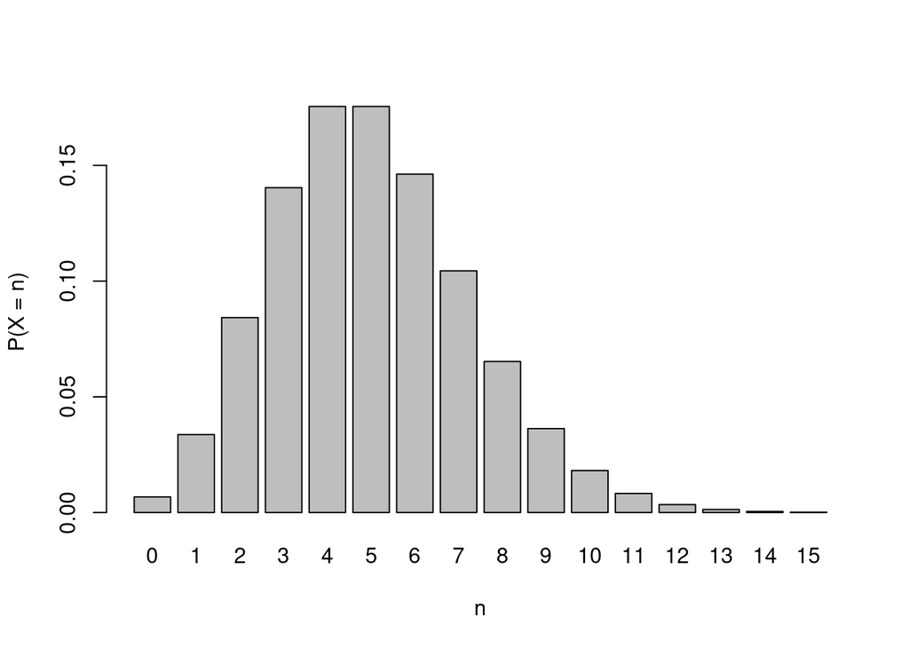

```r
n <- 0:15
barplot(dpois(n, lambda = 5), names.arg = n,
        xlab = "n", ylab = "P(X = n)")
```

Mode at n = 4 and n = 5 (equal heights).

- **QE2.3**. In a droplet-based single-cell experiment (e.g. 10x Genomics), the number of cells loaded into each droplet is approximately Poisson with mean λ. If you load at λ = 0.1 cells/droplet, what fraction of droplets are empty? What fraction contain exactly one cell? What fraction contain two or more (doublets)?

**Hint**

Empty = `dpois(0, λ)`. Singlets = `dpois(1, λ)`. Doublets (≥2) = `1 - ppois(1, λ)`.

**Hint**

This is exactly why droplet protocols deliberately under-load: low λ keeps doublets rare, at the cost of mostly-empty droplets.

**Solution**

```r
lambda <- 0.1
empty   <- dpois(0, lambda)
singlet <- dpois(1, lambda)
doublet <- 1 - ppois(1, lambda)
c(empty = empty, singlet = singlet, doublet = doublet)
```

```
     empty    singlet    doublet
0.90483742 0.09048374 0.00467884
```

About 90.5% empty, 9.05% singlets, and only ~0.47% doublets — the empty droplets are filtered out computationally afterwards.

### Statistical testing (extra)

- **QE3.1**. Using `diabetes.csv`, perform a t-test asking whether `Glucose` is higher in patients with `Outcome=1` than in those with `Outcome=0`.

**Hint**

Same pattern as Q4.1 but on the `Glucose` column. Use `alternative = "greater"` for a one-sided test.

**Solution**

```r
d <- read.csv("diabetes.csv")
glu_pos <- d$Glucose[d$Outcome == 1]
glu_neg <- d$Glucose[d$Outcome == 0]
t.test(glu_pos, glu_neg, alternative = "greater")
```

The p-value is extremely small — glucose is the strongest single separator of diabetic vs. non-diabetic in this dataset, as you might expect.

- **QE3.2**. Repeat QE3.1 but use `wilcox.test()` instead. The `Glucose` column has some zero values that almost certainly mean “missing”. Filter them out first and re-run both tests. How much does it change the p-value?

**Hint**

Subset with `d <- d[d$Glucose > 0, ]` before splitting.

**Solution**

```r
d <- read.csv("diabetes.csv")
d <- d[d$Glucose > 0, ]
glu_pos <- d$Glucose[d$Outcome == 1]
glu_neg <- d$Glucose[d$Outcome == 0]
t.test(glu_pos, glu_neg, alternative = "greater")
wilcox.test(glu_pos, glu_neg, alternative = "greater")
```

Both still give vanishingly small p-values — the effect is robust. Removing the zeros barely changes things because there are very few of them, but it’s the methodologically honest thing to do.

- **QE3.3**. Test whether `Age` differs between the two outcome groups. Is a one-sided or two-sided test more appropriate here? Justify.

**Hint**

A one-sided test is appropriate only when you have a prior directional hypothesis. Type 2 diabetes risk increases with age — so “greater in Outcome=1” is a defensible one-sided hypothesis.

**Solution**

```r
d <- read.csv("diabetes.csv")
t.test(Age ~ Outcome, data = d)                       # two-sided
t.test(Age ~ Outcome, data = d, alternative = "less") # H1: mean(0) < mean(1)
```

Either is defensible. A two-sided test is the safer default when in doubt; one-sided is fine if the directional hypothesis was pre-specified.

### Binomial (extra)

- **QE4.1**. Assume X ~ Binom(n=20, θ=0.3). What is P(X = 6)? What is P(X ≤ 6)?

**Hint**

`dbinom` for the point mass, `pbinom` for the cumulative.

**Solution**

```r
dbinom(6, size = 20, prob = 0.3)
```

```
[1] 0.191639
```

```r
pbinom(6, size = 20, prob = 0.3)
```

```
[1] 0.6080098
```

The mean is nθ = 6, so P(X = 6) is near the mode and P(X ≤ 6) sits a bit above 0.5.

- **QE4.2**. You sequence 50 reads at a position in the genome where the true allele frequency of a variant is θ = 0.5 (a heterozygous site). What is the probability of seeing ≤ 15 reads carrying the variant just by chance? Would seeing 15 or fewer be suspicious?

**Hint**

This is a one-sided binomial tail probability: `pbinom(15, size = 50, prob = 0.5)`.

**Solution**

```r
pbinom(15, size = 50, prob = 0.5)
```

```
[1] 0.003300224
```

About 0.0033 — seeing 15 or fewer would be quite unlikely under a true het. In practice this is exactly the kind of test used to flag allelic imbalance or genotyping errors.